# TNM Stan models

2016-12-12

```r
library(dplyr)
library(ggplot2)
library(rstan)
rstan_options(auto_write = TRUE)
options(mc.cores = parallel::detectCores())
ctl <- list(adapt_delta = 0.99) # more robust than the default
library(bayesplot)
# devtools::install_github("seananderson/stanhelpers") # if needed
library(stanhelpers)
```

# Data

This loads a file containing posterior distributions for six Trophic Niche Metrics (TNM): dNr, dCr, TA, CD, MNND, and SDNND, from 16 different reef sites. Data file also contains three reef variables: LFTADen (Lionfish density /100m2), HASAve (averaged score of habitat complexity), and lionfish removal treatment (binary, yes/no).

```r
d <- read.csv("data/FullCommNoLF.csv")
```

# Summarizing the response data

We can summarize the response data assuming it is log normally distributed:

```r
d_logged <- group_by(d, Site) %>%
  mutate_at(vars(dNr:SDNND), log)

d_means <- d_logged %>%
  summarize_all(mean)

d_sds <- d_logged %>%
  summarise_each(funs(sd), dNr:SDNND) %>%
  dplyr::select(-Site)
names(d_sds) <- paste0(names(d_sds), "_sd")

d_sum <- data.frame(d_means, d_sds)

d_sum <- d_sum %>% mutate(HASAve = arm::rescale(HASAve),
  LFTADen = arm::rescale(LFTADen),
  RemovTreat = arm::rescale(RemovTreat))

d_sum <- d_sum %>% left_join(readr::read_csv("data/SiteCoords.csv"))
```

The following plot shows the log transformed response data with our mean of the log transformed response data overlaid with a red line. For the most part these look approximately normally distributed and so our summary makes sense. The one variable that is a little bit off is SDNND. Still, I imagine this is close enough. If we wanted to get fancy, we could summarize these with something more flexible like a Gamma distribution.

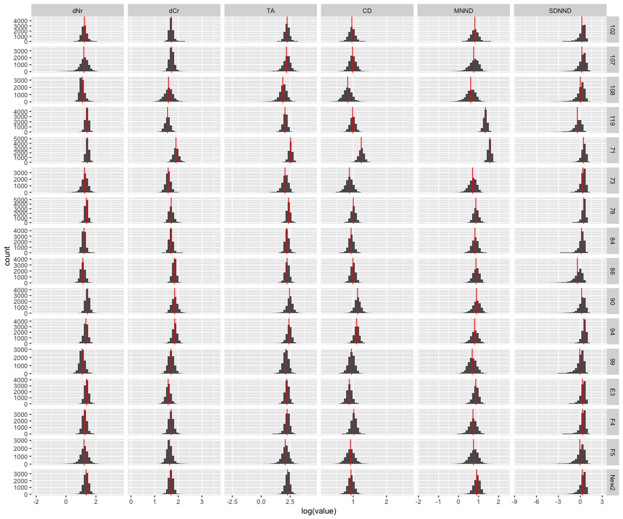

```r
d_sum_melt_mean <- select(d_sum, Site:SDNND) %>% reshape2::melt(id.vars = "Site")
d_sum_melt_sd <- select(d_sum, Site, dNr_sd:SDNND_sd) %>% reshape2::melt(id.vars = "Site")
d_melt <- select(d, Site:SDNND) %>% reshape2::melt(id.vars = "Site")

ggplot(d_melt, aes(log(value))) + geom_histogram(bins = 40) +
  facet_grid(Site~variable, scales = "free") +
  geom_vline(data = d_sum_melt_mean, aes(xintercept = value), colour = "red")
```

# Quick model

Let’s fit a quick linear model ignoring the uncertainty:

```r
m1 <- lm(dNr ~ HASAve + LFTADen * RemovTreat, data = d_sum)
arm::display(m1)
```

```
#> lm(formula = dNr ~ HASAve + LFTADen * RemovTreat, data = d_sum)
#>                    coef.est coef.se
#> (Intercept)         1.27     0.02
#> HASAve              0.14     0.05
#> LFTADen            -0.03     0.05
#> RemovTreat         -0.04     0.04
#> LFTADen:RemovTreat  0.22     0.10
#> ---
#> n = 16, k = 5
#> residual sd = 0.09, R-Squared = 0.60
```

# Stan

Same model to check:

```r
X <- model.matrix(dNr ~ 0 + HASAve + LFTADen * RemovTreat, data = d_sum)
stan_dat <- list(y_meas = d_sum$dNr, tau = d_sum$dNr_sd, N = nrow(d_sum), K = ncol(X), X = X)
```

```r
writeLines(readLines("tnm.stan"))
```

```
#> data {
#>   int N;               // number of observations
#>   int K;               // number of predictors
#>   real y_meas[N];      // measurement of y
#>   matrix[N, K] X;      // model predictor matrix
#> }
#> parameters {
#>   vector[K] beta;      // vector of predictors
#>   real alpha;          // intercept
#>   real<lower=0> sigma; // residual sd
#> }
#> model {
#>   sigma ~ student_t(3, 0, 1);  // prior
#>   alpha ~ student_t(3, 0, 10);  // prior
#>   beta ~ student_t(3, 0, 1);   // prior
#>   y_meas ~ normal(alpha + X * beta, sigma); // likelihood
#> }
```

```r
m_basic <- stan("tnm.stan", data = stan_dat, control = ctl)
```

```r
m_basic
```

```
#> Inference for Stan model: tnm.
#> 4 chains, each with iter=2000; warmup=1000; thin=1;
#> post-warmup draws per chain=1000, total post-warmup draws=4000.
#>
#>          mean se_mean   sd  2.5%   25%   50%   75% 97.5% n_eff Rhat
#> beta[1]  0.14    0.00 0.06  0.03  0.11  0.14  0.18  0.25  3097    1
#> beta[2] -0.03    0.00 0.06 -0.14 -0.07 -0.03  0.01  0.09  2639    1
#> beta[3] -0.04    0.00 0.05 -0.14 -0.07 -0.04 -0.01  0.06  3215    1
#> beta[4]  0.22    0.00 0.11  0.01  0.15  0.22  0.28  0.43  2047    1
#> alpha    1.27    0.00 0.02  1.23  1.26  1.27  1.29  1.32  3480    1
#> sigma    0.10    0.00 0.02  0.06  0.08  0.09  0.11  0.16  1668    1
#> lp__    27.71    0.05 2.06 22.51 26.67 28.13 29.20 30.48  1460    1
#>
#> Samples were drawn using NUTS(diag_e) at Mon Dec 12 21:24:43 2016.
#> For each parameter, n_eff is a crude measure of effective sample size,
#> and Rhat is the potential scale reduction factor on split chains (at
#> convergence, Rhat=1).
```

That looks the same to me.

# Measurement error model

Now let’s use the following model that allows for measurement error on y.

We can write the model as follows:

$$y_i \sim \mathrm{Normal} \left(y^\mathrm{true}_i, \tau_i^2\right),\\
y_i^\mathrm{true} = \beta_0 + \beta_1 H_i + \beta_2 L_i + \beta_3 R_i + + \beta_4 R_i L_i + \epsilon_{i},\\
\epsilon_i \sim \mathrm{Normal}(0, \sigma^2),$$

where $y_i$ and $\tau_i$ represent the mean and standard deviation of the log-transformed posterior of one of our response variables for site $i$, $y^\mathrm{true}_i$ represents the true unobserved value of that response variable, the $\beta$’s represent estimated coefficients, and $H_i$, $L_i$, and $R_i$ represent the habitat index variable, the lionfish density, and a binary variable representing whether lionfish were removed, respectively. The variable $\epsilon_i$ represents normally distributed residual error with mean 0 and standard deviation $\sigma$.

“True” may not be the correct term to use here. It’s not that it is necessarily “true”, but it is the response variable without the measurement uncertainty around it.

```r
writeLines(readLines("tnm-meas.stan"))
```

```
#> data {
#>   int N;               // number of observations
#>   int K;               // number of predictors
#>   real y_meas[N];      // measurement of y
#>   real<lower=0> tau[N];   // measurement sd on y
#>   matrix[N, K] X;      // model predictor matrix
#> }
#> parameters {
#>   vector[K] beta;      // vector of predictors
#>   real alpha;          // intercept
#>   real<lower=0> sigma; // residual sd
#>   real y_raw[N];
#> }
#> transformed parameters {
#>   real y[N];           // unknown true y value
#>   for (i in 1:N) {
#>     y[i] = alpha + X[i, ] * beta + sigma * y_raw[i]; // non-centered parameterization 'trick'
#>   }
#> }
#> model {
#>   sigma ~ student_t(3, 0, 1);  // prior
#>   alpha ~ student_t(3, 0, 10);  // prior
#>   beta ~ student_t(3, 0, 1);   // prior
#>   y_meas ~ normal(y, tau);     // measurement model
#>   y_raw ~ normal(0, 1);        // non-centered parameterization 'trick'
#> }
#> generated quantities{
#>   real y_pred[N];
#>   for (i in 1:N) {
#>     y_pred[i] = alpha + X[i, ] * beta;
#>   }
#> }
```

```r
m_meas <- stan("tnm-meas.stan", data = stan_dat,
  pars = c("y", "y_raw"), include = FALSE, control = ctl)
```

```r
m_meas
```

```
#> Inference for Stan model: tnm-meas.
#> 4 chains, each with iter=2000; warmup=1000; thin=1;
#> post-warmup draws per chain=1000, total post-warmup draws=4000.
#>
#>              mean se_mean   sd   2.5%    25%    50%    75% 97.5% n_eff
#> beta[1]      0.15    0.00 0.09  -0.03   0.09   0.15   0.21  0.33  4000
#> beta[2]     -0.05    0.00 0.13  -0.29  -0.14  -0.05   0.03  0.20  4000
#> beta[3]     -0.05    0.00 0.09  -0.22  -0.11  -0.05   0.00  0.12  4000
#> beta[4]      0.21    0.00 0.23  -0.25   0.06   0.21   0.37  0.66  4000
#> alpha        1.29    0.00 0.04   1.21   1.26   1.29   1.32  1.38  4000
#> sigma        0.05    0.00 0.04   0.00   0.02   0.04   0.07  0.16  2390
#> y_pred[1]    1.38    0.00 0.07   1.23   1.33   1.38   1.43  1.52  4000
#> y_pred[2]    1.28    0.00 0.13   1.03   1.20   1.28   1.36  1.52  4000
#> y_pred[3]    1.13    0.00 0.19   0.75   0.99   1.13   1.26  1.52  4000
#> y_pred[4]    1.36    0.00 0.09   1.17   1.30   1.36   1.42  1.54  4000
#> y_pred[5]    1.40    0.00 0.08   1.24   1.35   1.40   1.45  1.55  4000
#> y_pred[6]    1.36    0.00 0.08   1.19   1.30   1.36   1.41  1.53  4000
#> y_pred[7]    1.30    0.00 0.07   1.17   1.26   1.30   1.35  1.43  4000
#> y_pred[8]    1.33    0.00 0.06   1.22   1.29   1.33   1.37  1.44  4000
#> y_pred[9]    1.17    0.00 0.09   0.98   1.11   1.17   1.23  1.35  3301
#> y_pred[10]   1.35    0.00 0.06   1.22   1.31   1.35   1.39  1.47  4000
#> y_pred[11]   1.23    0.00 0.09   1.04   1.17   1.23   1.29  1.41  4000
#> y_pred[12]   1.12    0.00 0.13   0.88   1.04   1.12   1.21  1.38  4000
#> y_pred[13]   1.36    0.00 0.08   1.20   1.31   1.36   1.41  1.52  4000
#> y_pred[14]   1.23    0.00 0.07   1.08   1.18   1.23   1.28  1.38  3380
#> y_pred[15]   1.19    0.00 0.10   1.01   1.13   1.19   1.25  1.38  4000
#> y_pred[16]   1.37    0.00 0.18   1.03   1.25   1.37   1.49  1.73  4000
#> lp__       -15.35    0.09 3.50 -22.99 -17.55 -14.99 -12.88 -9.52  1395
#>            Rhat
#> beta[1]       1
#> beta[2]       1
#> beta[3]       1
#> beta[4]       1
#> alpha         1
#> sigma         1
#> y_pred[1]     1
#> y_pred[2]     1
#> y_pred[3]     1
#> y_pred[4]     1
#> y_pred[5]     1
#> y_pred[6]     1
#> y_pred[7]     1
#> y_pred[8]     1
#> y_pred[9]     1
#> y_pred[10]    1
#> y_pred[11]    1
#> y_pred[12]    1
#> y_pred[13]    1
#> y_pred[14]    1
#> y_pred[15]    1
#> y_pred[16]    1
#> lp__          1
#>
#> Samples were drawn using NUTS(diag_e) at Mon Dec 12 21:24:48 2016.
#> For each parameter, n_eff is a crude measure of effective sample size,
#> and Rhat is the potential scale reduction factor on split chains (at
#> convergence, Rhat=1).
```

We can inspect and plot the output:

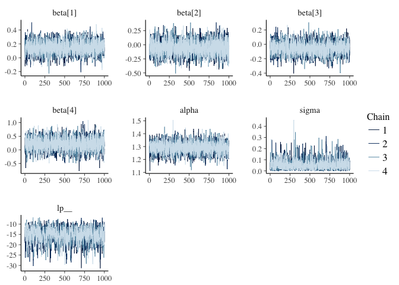

```r
posterior <- extract(m_meas, inc_warmup = FALSE, permuted = FALSE, pars = "y_pred",
  include = FALSE)
mcmc_trace(posterior)
```

```r
names(as.data.frame(X))
```

```
#> [1] "HASAve"             "LFTADen"            "RemovTreat"
#> [4] "LFTADen:RemovTreat"
```

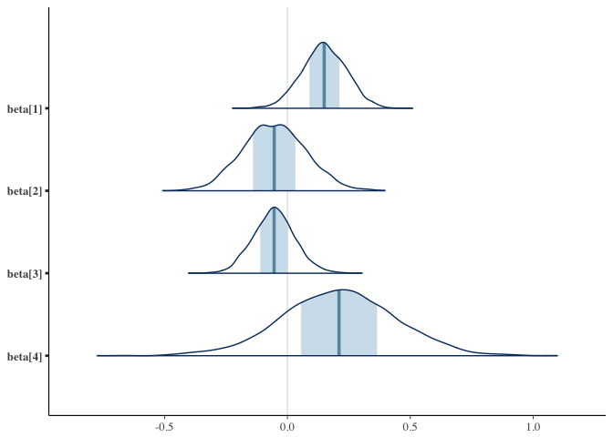

```r
mcmc_areas(as.matrix(m_meas), regex_pars = "beta")
```

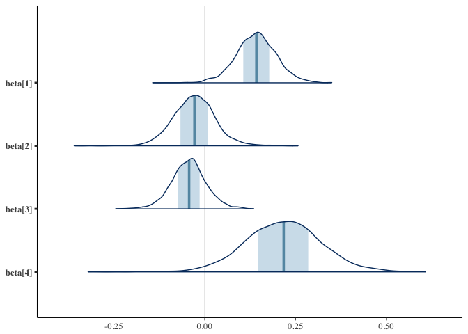

```r
mcmc_areas(as.matrix(m_basic), regex_pars = "beta")
```

So the posteriors are definitely wider in the case when we allow for the measurement error.

# Other responses

Now that the above models are working, let’s apply them to the various responses.

```r
fit_tnm <- function(response) {
  f <- paste(response, "~ 0 + HASAve + LFTADen * RemovTreat")
  X <- model.matrix(as.formula(f), data = d_sum)
  stan_dat <- list(y_meas = d_sum[, response], tau = d_sum$dNr_sd, N = nrow(d_sum),
    K = ncol(X), X = X)
  m <- stan("tnm-meas.stan", data = stan_dat,
    pars = c("y", "y_raw"), include = FALSE, control = list(adapt_delta = 0.99),
    iter = 3000, chains = 4)
  m
}
```

Now let’s apply the function to each of the responses.

```r
responses <- names(d)[2:7]
out_cent <- lapply(responses, fit_tnm)
names(out_cent) <- responses
```

Here we will extract the posteriors from the models and reformat the output for plotting. Also, we will calculate the effect of lionfish density for the case without removals (-0.5) and for the case with removals (0.5).

```r
stopifnot(identical(mean(d$RemovTreat), 0.5)) # Just in case!
p <- plyr::ldply(out_cent, stanhelpers::extract_df, output = "wide_df")
pred <- select(p, .id, starts_with("y_pred")) %>% rename(response = `.id`)
est <- select(p, .id, starts_with("beta")) %>% rename(response = `.id`)
names(est)[2:5] <- names(as.data.frame(X))
est <- mutate(est, LFTADen_w_removal = LFTADen + 0.5 * `LFTADen:RemovTreat`,
  LFTADen_no_removal = LFTADen - 0.5 * `LFTADen:RemovTreat`)
est <- reshape2::melt(est) # make a long format for ggplot
```

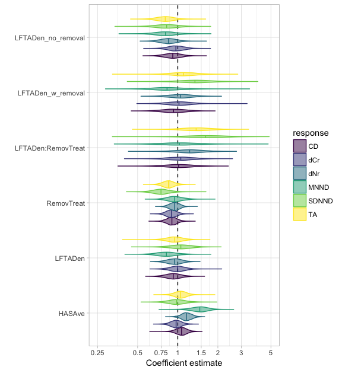

```r
labs <- c(0.25, 0.5, 0.75, 1, 1.5, 2, 3, 5)
ggplot(est, aes(variable, value, fill = response, colour = response)) +
  geom_hline(yintercept = 0, lty = 2) + xlab("") +
  scale_y_continuous(breaks = log(labs), labels = labs, limits = range(log(labs))) +
  geom_violin(position = position_dodge(width = 0.8), alpha = 0.5,
    draw_quantiles = 0.5) +
  coord_flip() +
  viridis::scale_fill_viridis(discrete = TRUE) +
  viridis::scale_color_viridis(discrete = TRUE) +
  theme_light() +
  ylab("Coefficient estimate")
```

```r
ggsave("figs/tnm-estimates.pdf", width = 6, height = 6.5)
```

In the above plot, I labeled the x axis with the exponentiated versions of the coefficients. These are the multiplicative effects. So, for example, a value of 0.6 means that the response will be 60% of what it was if the predictor increases by 2 standard deviations (or in the case of the treatment, the lionfish are removed).

We can calculate the probability a given coefficient is above or less than 0 (i.e. the multiplicative effect is above or below 1) (because this is a Bayesian model). You can use these values when you report results. We can also calculate lots of other things depending on what would be meaningful (e.g. credible intervals on the effects).

```r
sum_table <- est %>% group_by(variable, response) %>%
  summarize(
    prob_less_0 = round(sum(value < 0)/n(), 2),
    prob_above_0 = round(sum(value > 0)/n(), 2))
knitr::kable(sum_table)
```

| variable | response | prob_less_0 | prob_above_0 |
| --- | --- | --- | --- |
| HASAve | CD | 0.24 | 0.76 |
| HASAve | dCr | 0.62 | 0.38 |
| HASAve | dNr | 0.04 | 0.96 |
| HASAve | MNND | 0.01 | 0.99 |
| HASAve | SDNND | 0.55 | 0.45 |
| HASAve | TA | 0.31 | 0.69 |
| LFTADen | CD | 0.73 | 0.27 |
| LFTADen | dCr | 0.51 | 0.49 |
| LFTADen | dNr | 0.68 | 0.32 |
| LFTADen | MNND | 0.87 | 0.13 |
| LFTADen | SDNND | 0.38 | 0.62 |
| LFTADen | TA | 0.66 | 0.34 |
| RemovTreat | CD | 0.87 | 0.13 |
| RemovTreat | dCr | 0.88 | 0.12 |
| RemovTreat | dNr | 0.74 | 0.26 |
| RemovTreat | MNND | 0.67 | 0.33 |
| RemovTreat | SDNND | 0.97 | 0.03 |
| RemovTreat | TA | 0.94 | 0.06 |
| LFTADen:RemovTreat | CD | 0.47 | 0.53 |
| LFTADen:RemovTreat | dCr | 0.41 | 0.59 |
| LFTADen:RemovTreat | dNr | 0.18 | 0.82 |
| LFTADen:RemovTreat | MNND | 0.46 | 0.54 |
| LFTADen:RemovTreat | SDNND | 0.07 | 0.93 |
| LFTADen:RemovTreat | TA | 0.09 | 0.91 |
| LFTADen_w_removal | CD | 0.63 | 0.37 |
| LFTADen_w_removal | dCr | 0.45 | 0.55 |
| LFTADen_w_removal | dNr | 0.40 | 0.60 |
| LFTADen_w_removal | MNND | 0.75 | 0.25 |
| LFTADen_w_removal | SDNND | 0.15 | 0.85 |
| LFTADen_w_removal | TA | 0.31 | 0.69 |
| LFTADen_no_removal | CD | 0.73 | 0.27 |
| LFTADen_no_removal | dCr | 0.59 | 0.41 |
| LFTADen_no_removal | dNr | 0.88 | 0.12 |
| LFTADen_no_removal | MNND | 0.87 | 0.13 |
| LFTADen_no_removal | SDNND | 0.84 | 0.16 |
| LFTADen_no_removal | TA | 0.93 | 0.07 |

# Residuals

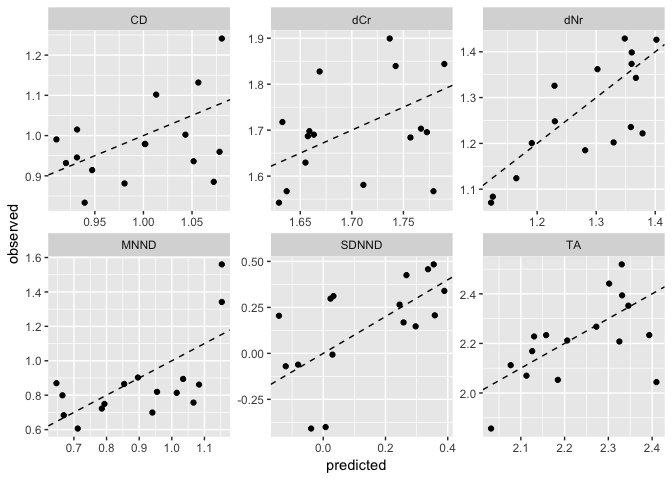

```r
p <- reshape2::melt(pred, variable.name = "site_i", value.name = "predicted")
p <- p %>% group_by(response, site_i) %>%
  summarise(predicted = mean(predicted))

obs <- select(d_sum, Site:SDNND, lat, lon) %>%
  reshape2::melt(id.vars = c("Site", "lat", "lon"), variable.name = "response",
    value.name = "observed")

stopifnot(identical(nrow(d_sum), length(unique(p$site_i)))) # just to check
lookup <- data_frame(Site = d_sum$Site, site_i = paste0("y_pred_", seq_len(nrow(d_sum))))
res <- inner_join(p, lookup) %>% inner_join(obs) %>%
  mutate(residual = observed - predicted)

ggplot(res, aes(predicted, observed)) + geom_point() +
  facet_wrap(~response, scales = "free") +
  geom_abline(intercept = 0, slope = 1, lty = 2)
```

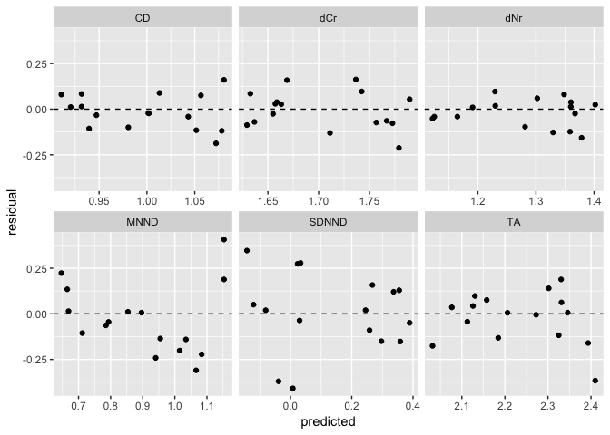

```r
ggplot(res, aes(predicted, residual)) + geom_point() +
  facet_wrap(~response, scales = "free_x") +
  geom_abline(intercept = 0, slope = 0, lty = 2)
```

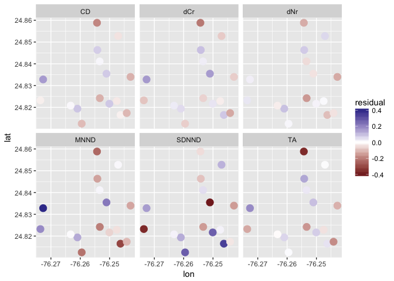

```r
ggsave("figs/fitted-vs-obs-tnm-residuals.pdf", width = 9, height = 6.5)

ggplot(res, aes(lon, lat, colour = residual)) + geom_point(size = 4) +
  facet_wrap(~response) +
  scale_color_gradient2()
```

```r
ggsave("figs/spatial-tnm-residuals.pdf", width = 10, height = 6.5)
```

Looks pretty good.

# Check mixing

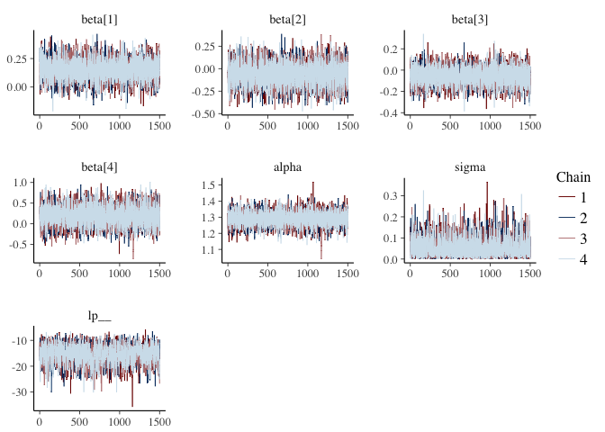

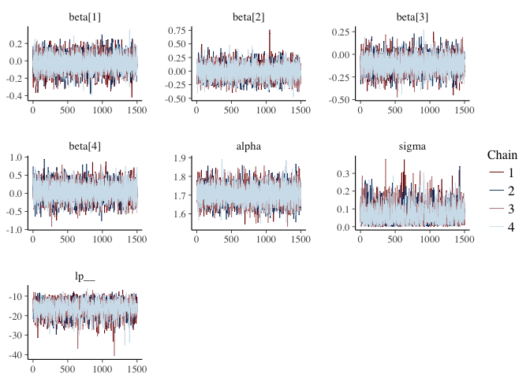

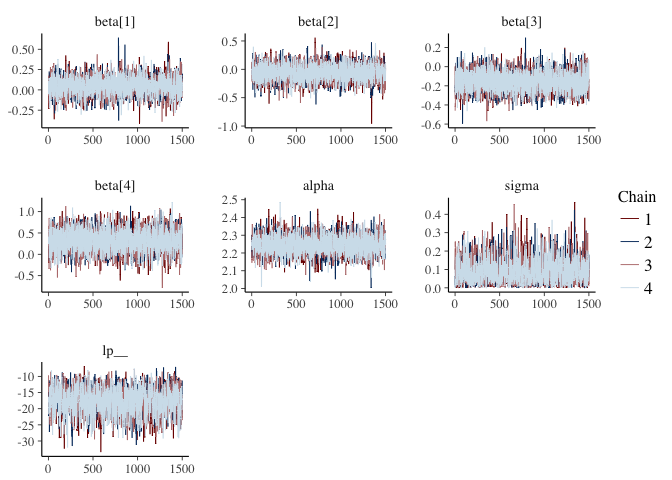

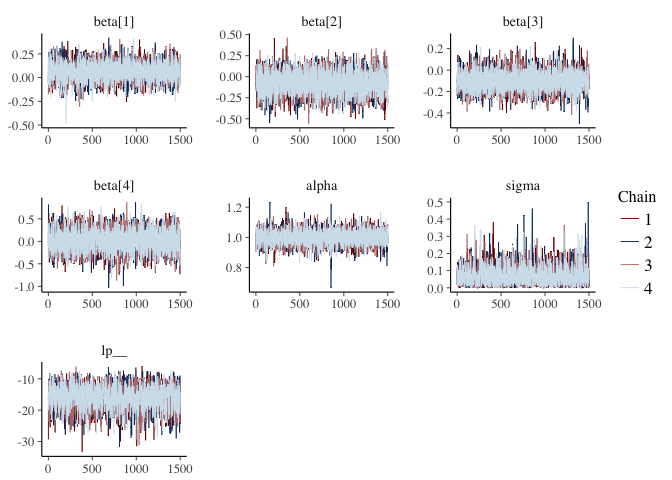

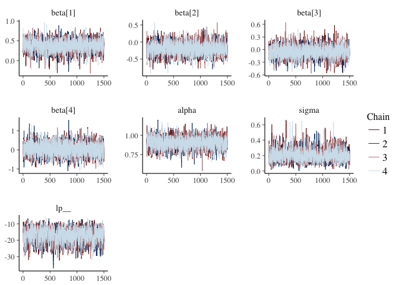

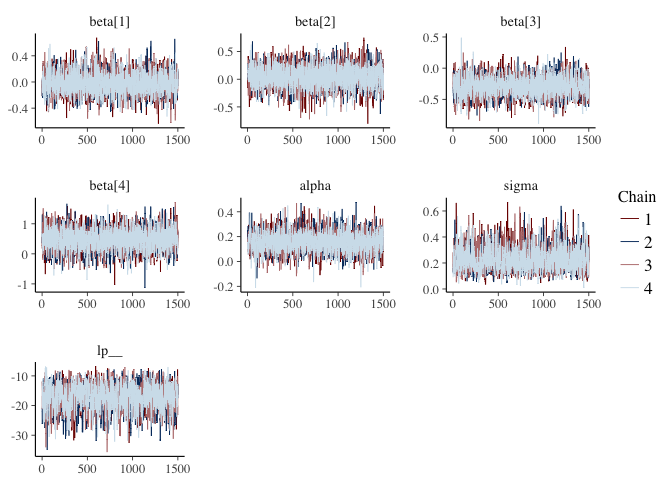

```r
color_scheme_set("mix-blue-red")
lapply(out_cent, function(x) mcmc_trace(extract(x, inc_warmup = FALSE, permuted = FALSE,
  pars = c("y_pred"), include = FALSE)))
```

```r
lapply(out_cent, function(x) {
  broom::tidyMCMC(x, rhat = TRUE, ess = TRUE) %>%
    filter(!grepl("y", term)) %>%
    select(term, rhat, ess) %>%
    mutate(rhat = round(rhat, 2), ess = round(ess, 2))
})
```

```
#> $dNr
#>      term rhat  ess
#> 1 beta[1]    1 6000
#> 2 beta[2]    1 6000
#> 3 beta[3]    1 6000
#> 4 beta[4]    1 6000
#> 5   alpha    1 6000
#> 6   sigma    1 3478
#>
#> $dCr
#>      term rhat  ess
#> 1 beta[1]    1 4761
#> 2 beta[2]    1 6000
#> 3 beta[3]    1 6000
#> 4 beta[4]    1 6000
#> 5   alpha    1 6000
#> 6   sigma    1 2359
#>
#> $TA
#>      term rhat  ess
#> 1 beta[1]    1 3780
#> 2 beta[2]    1 4605
#> 3 beta[3]    1 4493
#> 4 beta[4]    1 4692
#> 5   alpha    1 4393
#> 6   sigma    1 1874
#>
#> $CD
#>      term rhat  ess
#> 1 beta[1]    1 6000
#> 2 beta[2]    1 6000
#> 3 beta[3]    1 6000
#> 4 beta[4]    1 6000
#> 5   alpha    1 6000
#> 6   sigma    1 2599
#>
#> $MNND
#>      term rhat  ess
#> 1 beta[1]    1 2981
#> 2 beta[2]    1 3451
#> 3 beta[3]    1 3314
#> 4 beta[4]    1 4300
#> 5   alpha    1 3143
#> 6   sigma    1 2027
#>
#> $SDNND
#>      term rhat  ess
#> 1 beta[1]    1 2876
#> 2 beta[2]    1 3433
#> 3 beta[3]    1 3263
#> 4 beta[4]    1 3684
#> 5   alpha    1 3042
#> 6   sigma    1 1998
```

Looks great.

# Credible intervals

```r
intervals <- group_by(est, response, variable) %>%
  summarize(
    q0.025 = quantile(value, probs = 0.025),
    q0.25 = quantile(value, probs = 0.25),
    q0.5 = quantile(value, probs = 0.5),
    q0.75 = quantile(value, probs = 0.75),
    q0.975 = quantile(value, probs = 0.975))

intervals_rounded <- intervals %>%
  mutate_at(vars(q0.025:q0.975), round, digits = 2)

knitr::kable(intervals_rounded)
```

| response | variable | q0.025 | q0.25 | q0.5 | q0.75 | q0.975 |
| --- | --- | --- | --- | --- | --- | --- |
| CD | HASAve | -0.12 | 0.00 | 0.07 | 0.13 | 0.25 |
| CD | LFTADen | -0.34 | -0.16 | -0.08 | 0.01 | 0.18 |
| CD | RemovTreat | -0.27 | -0.16 | -0.10 | -0.04 | 0.08 |
| CD | LFTADen:RemovTreat | -0.43 | -0.13 | 0.02 | 0.17 | 0.48 |
| CD | LFTADen_w_removal | -0.47 | -0.20 | -0.07 | 0.07 | 0.33 |
| CD | LFTADen_no_removal | -0.36 | -0.18 | -0.09 | 0.01 | 0.19 |
| dCr | HASAve | -0.22 | -0.09 | -0.03 | 0.03 | 0.16 |
| dCr | LFTADen | -0.25 | -0.09 | -0.01 | 0.08 | 0.25 |
| dCr | RemovTreat | -0.28 | -0.17 | -0.11 | -0.05 | 0.07 |
| dCr | LFTADen:RemovTreat | -0.41 | -0.10 | 0.05 | 0.20 | 0.51 |
| dCr | LFTADen_w_removal | -0.38 | -0.11 | 0.02 | 0.16 | 0.41 |
| dCr | LFTADen_no_removal | -0.31 | -0.12 | -0.03 | 0.06 | 0.24 |
| dNr | HASAve | -0.03 | 0.09 | 0.15 | 0.21 | 0.33 |
| dNr | LFTADen | -0.30 | -0.14 | -0.06 | 0.03 | 0.18 |
| dNr | RemovTreat | -0.22 | -0.11 | -0.06 | 0.00 | 0.11 |
| dNr | LFTADen:RemovTreat | -0.26 | 0.06 | 0.21 | 0.36 | 0.67 |
| dNr | LFTADen_w_removal | -0.35 | -0.08 | 0.05 | 0.18 | 0.44 |
| dNr | LFTADen_no_removal | -0.42 | -0.25 | -0.16 | -0.07 | 0.11 |
| MNND | HASAve | 0.07 | 0.28 | 0.38 | 0.47 | 0.66 |
| MNND | LFTADen | -0.53 | -0.31 | -0.19 | -0.08 | 0.16 |
| MNND | RemovTreat | -0.31 | -0.14 | -0.05 | 0.03 | 0.22 |
| MNND | LFTADen:RemovTreat | -0.58 | -0.17 | 0.03 | 0.24 | 0.67 |
| MNND | LFTADen_w_removal | -0.70 | -0.35 | -0.18 | 0.00 | 0.38 |
| MNND | LFTADen_no_removal | -0.58 | -0.33 | -0.21 | -0.09 | 0.18 |
| SDNND | HASAve | -0.31 | -0.11 | -0.02 | 0.08 | 0.31 |
| SDNND | LFTADen | -0.32 | -0.07 | 0.05 | 0.17 | 0.40 |
| SDNND | RemovTreat | -0.57 | -0.38 | -0.29 | -0.20 | 0.00 |
| SDNND | LFTADen:RemovTreat | -0.20 | 0.27 | 0.48 | 0.70 | 1.14 |
| SDNND | LFTADen_w_removal | -0.29 | 0.11 | 0.30 | 0.48 | 0.85 |
| SDNND | LFTADen_no_removal | -0.59 | -0.32 | -0.19 | -0.06 | 0.22 |
| TA | HASAve | -0.16 | -0.02 | 0.05 | 0.12 | 0.25 |
| TA | LFTADen | -0.32 | -0.14 | -0.06 | 0.04 | 0.21 |
| TA | RemovTreat | -0.34 | -0.22 | -0.16 | -0.09 | 0.04 |
| TA | LFTADen:RemovTreat | -0.16 | 0.16 | 0.32 | 0.48 | 0.79 |
| TA | LFTADen_w_removal | -0.31 | -0.04 | 0.10 | 0.25 | 0.53 |
| TA | LFTADen_no_removal | -0.50 | -0.31 | -0.22 | -0.12 | 0.08 |

# brms package checks

Similar, but subtly different models as checks (ignore).

```r
# library(brms)
# m2 <- brm(dNr ~ 1 + HASAve + LFTADen * RemovTreat, data = d_sum)

# m3 <- brm(dNr | se(dNr_sd) ~ 1 + HASAve + LFTADen * RemovTreat, data = d_sum,
#   prior = c(prior(student_t(5, 0, 2), class = "b"), prior(student_t(5, 0, 5), class = "Intercept")))

# m4 <- brm(dNr | se(dNr_sd) ~ 1 + HASAve + LFTADen * RemovTreat + (1|Site), data = d_sum,
#   control = list(adapt_delta = 0.99),
#   prior = c(prior(student_t(5, 0, 2), class = "b"),
#     prior(student_t(5, 0, 5), class = "Intercept"),
#     prior(student_t(5, 0, 2), class = "sd")))
```